# UC00207_Dynamic_Electricity_Demand_Forecasting_for_Smart_Cities

Dynamic Electricity Demand Forecasting for Smart Cities

**Authored by:** Venkata Rama Kartikeya Bulusu

**Duration:** 90 mins

**Level:** Intermediate

**Pre-requisite Skills:** Python,Matplotlib,NumPy,Pandas,Data Visualisation

## Scenario

Electricity demand in modern smart cities changes continuously due to daily routines, seasonal variations, and human activity patterns. Accurate demand forecasting is essential for efficient energy distribution, preventing overload, and supporting smart grid operations. In this use case, historical electricity consumption data from the UCI Electricity Load dataset is used to model temporal demand patterns and develop a Long Short-Term Memory (LSTM) forecasting system. By learning from past consumption behaviour across multiple clients, the model predicts future electricity demand and helps simulate neighbourhood-level load forecasting for smart city energy planning.

## User Story

As a smart grid analyst or urban energy planner, I want to forecast future electricity demand using historical consumption data so that I can anticipate peak usage periods, improve energy distribution efficiency, and support better decision-making in smart city power management systems.

## What this use case will teach you

- Working with real electricity consumption time-series data.
- Identifying temporal patterns in energy usage.
- Preparing sequential data for forecasting models.
- Aggregating multiple signals to represent larger demand profiles.
- Training a Long Short-Term Memory (LSTM) network for prediction.
- Evaluating forecasting performance using numerical metrics.
- Visualising predicted and actual electricity demand.
- Understanding the role of demand forecasting in smart grid systems.

# Introduction

Electricity demand forecasting plays a critical role in smart city infrastructure, where energy providers must continuously balance supply and demand across residential, commercial, and industrial areas. Consumption patterns are influenced by time-of-day behaviour, weekly cycles, and seasonal trends, making the forecasting task highly nonlinear and difficult to model using traditional statistical approaches. This project uses the UCI Electricity Load dataset, which contains time-series electricity consumption measurements for multiple clients over several years. A Long Short-Term Memory (LSTM) neural network is used to learn temporal dependencies in the data and predict future electricity demand. The forecasting results can help simulate smart grid scenarios, support peak demand planning, and improve energy management strategies in urban environments.

# Dataset

## UCI Electricity Load Dataset

This use case uses the UCI Electricity Load Diagrams 2011–2014 dataset, which contains electricity consumption measurements recorded over time for multiple clients.

- The dataset includes -
- Electricity usage readings collected at regular time intervals
- Data from multiple clients representing different consumption profiles
- Long time-series covering several years
- High-frequency measurements suitable for temporal analysis
- Numerical consumption values that can be aggregated or analysed individually
- How the dataset can be used in this use case: —
  - Individual client consumption can represent household or building demand
  - Multiple clients can be combined to simulate neighbourhood-level electricity usage
  - The time-series structure allows modelling of daily, weekly, and seasonal patterns
  - The dataset provides sufficient history for training deep learning forecasting models

**Reason for Using only UCI Electricity Dataset**

The UCI Electricity dataset alone is used in this use case because it already provides a large and consistent time-series of electricity consumption data suitable for forecasting tasks. Using a single dataset avoids complications caused by combining data from different locations, formats, or time ranges, while still allowing realistic smart city demand simulation by aggregating multiple client loads. The size and duration of the dataset are sufficient for training and evaluating an LSTM forecasting model without requiring additional data sources.

# Project Goals

1. **Prepare and preprocess electricity consumption time-series data:** Clean and structure the UCI Electricity dataset so that it can be used for time-series forecasting.
2. **Analyse temporal demand patterns:** Explore daily, weekly, and seasonal electricity usage trends to understand consumption behaviour.
3. **Aggregate client data to simulate neighbourhood-level demand:** Combine multiple client consumption values to represent energy usage in a smart city environment.
4. **Develop an LSTM forecasting model :** Train a Long Short-Term Memory neural network to learn temporal dependencies in electricity demand.
5. **Predict future electricity consumption:** Use the trained model to forecast upcoming demand values based on historical data.
6. **Evaluate forecasting performance :** Measure prediction accuracy using appropriate regression metrics and visualise predicted vs actual demand
7. **Support smart grid decision-making :** Interpret forecasting results to show how demand prediction can help with peak load management and efficient energy distribution.

## Importing Packages

```python
# Importing modules
import pandas as pd
import numpy as np
import matplotlib.pyplot as plt
import seaborn as sns
from sklearn.preprocessing import MinMaxScaler
from statsmodels.graphics.tsaplots import plot_acf
import tensorflow as tf
from tensorflow.keras.models import Sequential
from tensorflow.keras.layers import LSTM, Dense, Dropout
from tensorflow.keras.callbacks import EarlyStopping, ReduceLROnPlateau
from tensorflow.keras.layers import Conv1D, MaxPooling1D, Input
from tensorflow.keras.models import Model
from sklearn.metrics import mean_squared_error, mean_absolute_error
```

## Importing and Loading Dataset

### Installing Darts Library

The Darts library is installed to simplify time-series forecasting tasks. It provides built-in datasets, preprocessing tools, and advanced forecasting models such as LSTM, ARIMA, and more.

This step ensures the environment has the required package before loading the dataset.

```python
pip install darts
```

The UCI Electricity Load Diagrams 2011–2014 dataset is loaded using the darts library's built-in ElectricityDataset class. darts is a professional-grade Python library for time series forecasting developed and maintained by Unit8, which hosts several benchmark datasets including the UCI Electricity dataset directly within the library. This approach ensures the notebook remains fully reproducible and portable, as the dataset is fetched and loaded into memory at runtime without requiring any manual setup or external configuration. The loaded dataset contains electricity consumption readings for 370 clients (labelled MT_001 to MT_370) recorded at 15-minute intervals from January 2011 to December 2014, resulting in 140,256 timesteps across 370 columns. Each client represents an individual electricity consumer whose readings can be analysed independently or aggregated to simulate neighbourhood-level demand, directly supporting the smart city forecasting objectives of this project.

```python
from darts.datasets import ElectricityDataset

series = ElectricityDataset().load()
df = series.to_dataframe()
print(df.shape)
print(df.head())
```

```
(140256, 370)
                     MT_001  MT_002  MT_003  MT_004  MT_005  MT_006  MT_007  \
Unnamed: 0
2011-01-01 00:15:00     0.0     0.0     0.0     0.0     0.0     0.0     0.0
2011-01-01 00:30:00     0.0     0.0     0.0     0.0     0.0     0.0     0.0
2011-01-01 00:45:00     0.0     0.0     0.0     0.0     0.0     0.0     0.0
2011-01-01 01:00:00     0.0     0.0     0.0     0.0     0.0     0.0     0.0
2011-01-01 01:15:00     0.0     0.0     0.0     0.0     0.0     0.0     0.0

                     MT_008  MT_009  MT_010  ...  MT_361  MT_362  MT_363  \
Unnamed: 0                                   ...
2011-01-01 00:15:00     0.0     0.0     0.0  ...     0.0     0.0     0.0
2011-01-01 00:30:00     0.0     0.0     0.0  ...     0.0     0.0     0.0
2011-01-01 00:45:00     0.0     0.0     0.0  ...     0.0     0.0     0.0
2011-01-01 01:00:00     0.0     0.0     0.0  ...     0.0     0.0     0.0
2011-01-01 01:15:00     0.0     0.0     0.0  ...     0.0     0.0     0.0

                     MT_364  MT_365  MT_366  MT_367  MT_368  MT_369  MT_370
Unnamed: 0
2011-01-01 00:15:00     0.0     0.0     0.0     0.0     0.0     0.0     0.0
2011-01-01 00:30:00     0.0     0.0     0.0     0.0     0.0     0.0     0.0
2011-01-01 00:45:00     0.0     0.0     0.0     0.0     0.0     0.0     0.0
2011-01-01 01:00:00     0.0     0.0     0.0     0.0     0.0     0.0     0.0
2011-01-01 01:15:00     0.0     0.0     0.0     0.0     0.0     0.0     0.0

[5 rows x 370 columns]
```

## Preprocessing the Dataset

### Fixing the Datetime Index and Removing Empty Records

This cell performs key data cleaning steps. First, the DataFrame index is renamed to datetime to clearly represent the time dimension. Then, rows where all values are zero are removed. These rows typically occur at the beginning of the dataset where no electricity usage was recorded. Removing them ensures the analysis begins with valid observations.

```python
# Fix index name
df.index.name = "datetime"

# Drop rows where all clients are zero (leading empty records from clients added after 2011)
df = df[(df != 0).any(axis=1)]
print(f"Shape after removing leading zeros: {df.shape}")
print(f"Data starts from: {df.index[0]}")
```

```
Shape after removing leading zeros: (140256, 370)
Data starts from: 2011-01-01 00:15:00
```

### Resampling Data to Hourly Frequency

The dataset originally contains readings at 15-minute intervals. This cell converts the data into hourly values by aggregating four consecutive readings. Resampling reduces noise and makes the dataset more suitable for forecasting electricity demand at a neighbourhood level.

```python
# Resample from 15-minute intervals to hourly by summing 4 readings per hour
df_hourly = df.resample("h").sum()
print(f"Shape after resampling to hourly: {df_hourly.shape}")
```

```
Shape after resampling to hourly: (35065, 370)
```

### Aggregating Total Electricity Demand

This step combines all individual client consumption values into a single time-series representing total neighbourhood demand. By summing across all clients, the dataset is simplified into one feature that reflects overall electricity usage, making it more suitable for forecasting.

```python
# Aggregate all 370 clients into a single neighbourhood-level demand signal
neighbourhood_demand = df_hourly.sum(axis=1).to_frame(name="total_demand")
print(neighbourhood_demand.head())
```

```
                      total_demand
datetime
2011-01-01 00:00:00  207058.270272
2011-01-01 01:00:00  265378.510747
2011-01-01 02:00:00  263924.219533
2011-01-01 03:00:00  266306.134264
2011-01-01 04:00:00  259854.210701
```

### Normalising the Demand Values

This cell applies Min-Max scaling to transform demand values into a range between 0 and 1. Normalisation is essential for neural network models such as LSTM, as it improves training stability and ensures that all values are on a comparable scale.

```python
# Normalise demand values to 0–1 range — required for stable LSTM training
scaler = MinMaxScaler()
scaled = scaler.fit_transform(neighbourhood_demand)
print(f"Min: {scaled.min():.4f}, Max: {scaled.max():.4f}")
```

```
Min: 0.0000, Max: 1.0000
```

### Checking for Missing Values

This cell checks whether there are any missing values in the dataset after preprocessing. Ensuring completeness of the data is important for reliable model training and accurate forecasting results.

```python
# Check 1 — missing values after resampling
print("Missing values:")
print(neighbourhood_demand.isnull().sum())
```

```
Missing values:
total_demand    0
dtype: int64
```

### Detecting Outliers in Demand Data

This step identifies extreme values in the dataset using the three-standard-deviation rule. Values that are significantly higher than the average are flagged as outliers. Detecting these helps prevent abnormal data from affecting model performance.

```python
# Check 2 — outliers (values beyond 3 standard deviations)
mean = neighbourhood_demand["total_demand"].mean()
std  = neighbourhood_demand["total_demand"].std()
outliers = neighbourhood_demand[neighbourhood_demand["total_demand"] > mean + 3*std]
print(f"Outlier count: {len(outliers)}")
print(outliers.head())
```

```
Outlier count: 2
                     total_demand
datetime
2012-08-10 16:00:00  1.792595e+06
2013-07-09 17:00:00  1.790418e+06
```

### Checking for Duplicate Time Entries

This cell verifies whether any duplicate timestamps exist in the dataset. Each time point should correspond to a single observation, and duplicates can disrupt the sequence and lead to inaccurate forecasting results.

```python
# Check 3 — duplicate timestamps
print(f"Duplicate timestamps: {neighbourhood_demand.index.duplicated().sum()}")
```

```
Duplicate timestamps: 0
```

### Verifying Time Continuity

This step checks whether the datetime index is continuous without any missing intervals. A complete and consistent time sequence is essential for time-series modelling and ensures the model correctly learns temporal patterns.

```python
# Check 4 — continuity of datetime index
expected = pd.date_range(start=neighbourhood_demand.index[0],
                         end=neighbourhood_demand.index[-1], freq="h")
missing_timestamps = expected.difference(neighbourhood_demand.index)
print(f"Missing timestamps: {len(missing_timestamps)}")
```

```
Missing timestamps: 0
```

### Handling Outliers by Capping

Extreme values are limited by capping them at a defined upper threshold based on the mean and standard deviation. This reduces the impact of unusually high demand values while preserving the overall data distribution.

```python
# Cap outliers beyond 3 standard deviations with the upper bound value
mean = neighbourhood_demand["total_demand"].mean()
std  = neighbourhood_demand["total_demand"].std()
upper_bound = mean + 3 * std

neighbourhood_demand["total_demand"] = neighbourhood_demand["total_demand"].clip(upper=upper_bound)

print(f"Outliers capped at: {upper_bound:.2f}")
print(f"Max value after capping: {neighbourhood_demand['total_demand'].max():.2f}")
```

```
Outliers capped at: 1788945.71
Max value after capping: 1788945.71
```

```python
print(df.shape)
print(df_hourly.shape)
print(neighbourhood_demand.head())
print(neighbourhood_demand.shape)
```

```
(140256, 370)
(35065, 370)
                      total_demand
datetime
2011-01-01 00:00:00  207058.270272
2011-01-01 01:00:00  265378.510747
2011-01-01 02:00:00  263924.219533
2011-01-01 03:00:00  266306.134264
2011-01-01 04:00:00  259854.210701
(35065, 1)
```

## Exploratory Data Analysis

### Overall Demand Trend

[figure not shown]

```python
plt.figure(figsize=(15, 4))
plt.plot(neighbourhood_demand.index, neighbourhood_demand["total_demand"],
         color="steelblue", linewidth=0.5)
plt.title("Neighbourhood Electricity Demand (2012–2014)")
plt.xlabel("Date")
plt.ylabel("Total Demand (kWh)")
plt.tight_layout()
plt.show()
```

### Average Demand by Hour of Day

To understand how electricity consumption varies across different times of the day, we extract the hour from the datetime index and compute the average demand for each hour. This daily demand profile is fundamental to smart grid planning as it reveals morning and evening peak periods which are critical for load management and demand-response strategies.

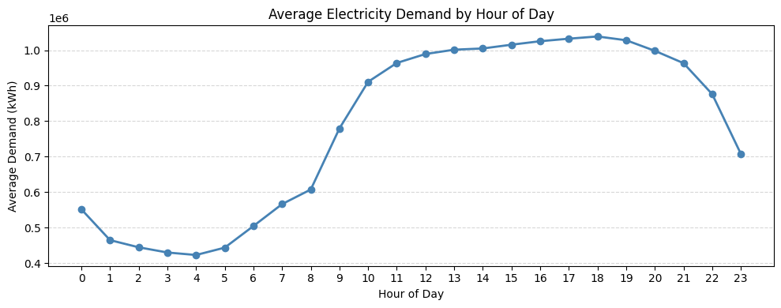

```python
neighbourhood_demand["hour"] = neighbourhood_demand.index.hour
hourly_avg = neighbourhood_demand.groupby("hour")["total_demand"].mean()

plt.figure(figsize=(10, 4))
plt.plot(hourly_avg.index, hourly_avg.values, marker="o", color="steelblue", linewidth=2)
plt.title("Average Electricity Demand by Hour of Day")
plt.xlabel("Hour of Day")
plt.ylabel("Average Demand (kWh)")
plt.xticks(range(0, 24))
plt.grid(axis="y", linestyle="--", alpha=0.5)
plt.tight_layout()
plt.show()
```

The hourly average demand profile reveals a single broad peak pattern rather than the dual-peak pattern typically associated with purely residential consumption. Demand reaches its lowest point between 3 am and 4 am at approximately 420,000 kWh, which represents the overnight trough when the vast majority of activity across the neighbourhood ceases. From 6 am onwards demand rises sharply and continuously, reflecting the morning start-up of both residential and commercial activity, and by 10 am it has already surpassed 900,000 kWh. The demand then plateaus at a consistently high level between 10 am and 6 pm, hovering around 1,000,000 to 1,040,000 kWh, which indicates a strong commercial and industrial contribution to the neighbourhood's total load during standard business hours. The absolute peak occurs at 18:00 (6 pm) at just over 1,040,000 kWh, after which demand begins a steady decline through the evening hours, dropping to approximately 700,000 kWh by 11 pm. This extended midday plateau combined with an evening peak strongly confirms that the dataset represents a mix of commercial and residential consumers.

### Average Demand by Day of Week

Weekly consumption patterns reveal how electricity demand differs between weekdays and weekends. In urban smart city environments, weekday demand is typically driven by commercial and industrial activity whilst weekend demand reflects predominantly residential usage. This distinction is important for building accurate forecasting models that account for behavioural differences across the week.

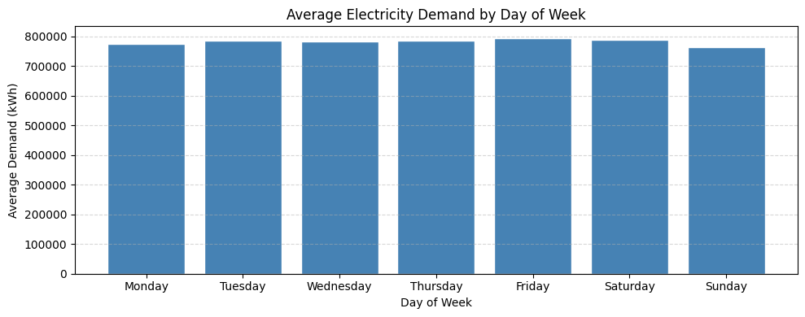

```python
neighbourhood_demand["dayofweek"] = neighbourhood_demand.index.dayofweek
daily_avg = neighbourhood_demand.groupby("dayofweek")["total_demand"].mean()
days = ["Monday", "Tuesday", "Wednesday", "Thursday", "Friday", "Saturday", "Sunday"]

plt.figure(figsize=(10, 4))
plt.bar(days, daily_avg.values, color="steelblue", edgecolor="white")
plt.title("Average Electricity Demand by Day of Week")
plt.xlabel("Day of Week")
plt.ylabel("Average Demand (kWh)")
plt.grid(axis="y", linestyle="--", alpha=0.5)
plt.tight_layout()
plt.show()
```

The day-of-week bar chart reveals a remarkably uniform distribution of electricity demand across all seven days, with average consumption sitting consistently between 760,000 and 800,000 kWh regardless of the day. Unlike typical purely residential datasets where weekends show a pronounced drop in consumption, this dataset displays only a very marginal difference between weekdays and weekends — Sunday records the lowest average at approximately 762,000 kWh whilst Friday records the highest at just over 795,000 kWh, a difference of less than 5%. This near-uniform pattern strongly reinforces the conclusion drawn from the hourly plot that the dataset is dominated by a large commercial and industrial consumer base whose electricity usage does not vary significantly across the working week.

### Seasonal Demand Patterns

Seasonal analysis is critical for electricity demand forecasting as consumption patterns shift significantly across different months of the year. Winter months typically see higher demand due to heating whilst summer months reflect increased cooling loads, particularly during heatwaves — a scenario directly relevant to smart grid planning and the core motivation of this use case.

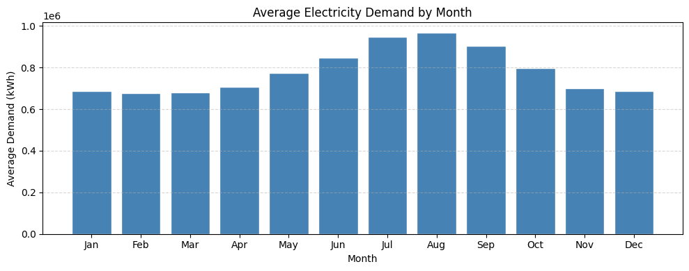

```python
neighbourhood_demand["month"] = neighbourhood_demand.index.month
monthly_avg = neighbourhood_demand.groupby("month")["total_demand"].mean()
months = ["Jan", "Feb", "Mar", "Apr", "May", "Jun",
          "Jul", "Aug", "Sep", "Oct", "Nov", "Dec"]

plt.figure(figsize=(10, 4))
plt.bar(months, monthly_avg.values, color="steelblue", edgecolor="white")
plt.title("Average Electricity Demand by Month")
plt.xlabel("Month")
plt.ylabel("Average Demand (kWh)")
plt.grid(axis="y", linestyle="--", alpha=0.5)
plt.tight_layout()
plt.show()
```

The monthly average demand bar chart clearly confirms the strong seasonal nature of electricity consumption in this dataset and provides an important geographical insight. Demand is at its lowest during January, February, March, and December, all sitting around 680,000 kWh, whilst it peaks sharply during July and August at approximately 950,000 and 970,000 kWh respectively — nearly 40% higher than the winter months. This pattern where peak consumption occurs in the middle of the calendar year rather than at the year's end is characteristic of a Northern Hemisphere country experiencing its hottest summer period between June and September, consistent with Portugal where this dataset originates. The steady ramp-up from April through to August and the gradual decline from September through to December follows a smooth unimodal seasonal curve driven primarily by summer cooling loads such as air conditioning and industrial refrigeration rather than winter heating. This finding is directly relevant to the smart city forecasting objective as it confirms that the LSTM model must learn to associate mid-year periods with significantly elevated demand precisely the kind of long-range seasonal dependency that makes deep learning approaches more appropriate than traditional short-window statistical models for this forecasting task.

### Rolling Average Trend

A rolling average smooths out short-term fluctuations in the demand signal and makes long-term seasonal trends more visible. Here we apply a 7-day (168-hour) rolling mean over the neighbourhood demand series. This is particularly useful for identifying gradual shifts in consumption behaviour across seasons and confirming that the data contains the cyclic patterns that an LSTM model is well-suited to learn.

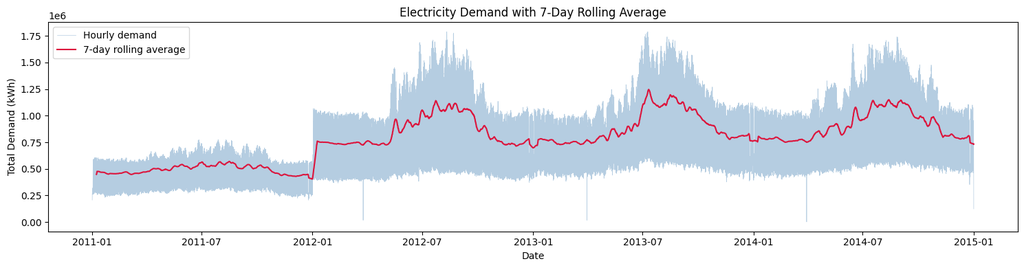

```python
rolling_avg = neighbourhood_demand["total_demand"].rolling(window=168).mean()

plt.figure(figsize=(15, 4))
plt.plot(neighbourhood_demand.index, neighbourhood_demand["total_demand"],
         color="steelblue", linewidth=0.5, alpha=0.4, label="Hourly demand")
plt.plot(neighbourhood_demand.index, rolling_avg,
         color="crimson", linewidth=1.5, label="7-day rolling average")
plt.title("Electricity Demand with 7-Day Rolling Average")
plt.xlabel("Date")
plt.ylabel("Total Demand (kWh)")
plt.legend()
plt.tight_layout()
plt.show()
```

### Demand Distribution

A distribution plot of the total demand values helps us understand the statistical spread of electricity consumption across the dataset. It reveals whether the demand signal follows a roughly normal distribution, whether it is skewed, and confirms that the outlier capping applied during preprocessing has resulted in a clean, bounded distribution suitable for model training.

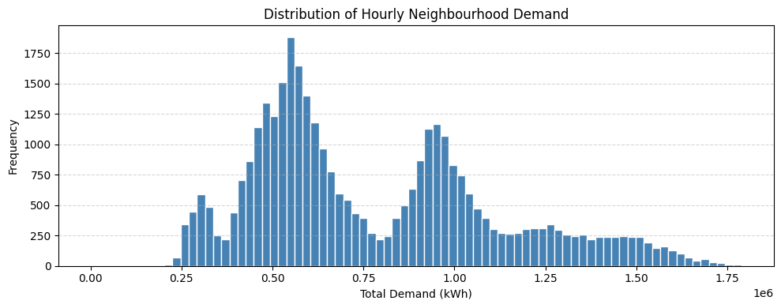

```python
plt.figure(figsize=(10, 4))
plt.hist(neighbourhood_demand["total_demand"], bins=80,
         color="steelblue", edgecolor="white")
plt.title("Distribution of Hourly Neighbourhood Demand")
plt.xlabel("Total Demand (kWh)")
plt.ylabel("Frequency")
plt.grid(axis="y", linestyle="--", alpha=0.5)
plt.tight_layout()
plt.show()
```

The distribution of hourly neighbourhood demand reveals a clearly bimodal pattern — a highly distinctive characteristic that ties directly back to the findings from the earlier EDA plots. The first and taller peak centres around 500,000 to 550,000 kWh and represents the winter and overnight demand regime, corresponding to the lower consumption periods identified in the seasonal and hourly analyses. The second peak centres around 950,000 to 1,000,000 kWh and represents the summer daytime demand regime, driven by the elevated cooling loads observed during the mid-year peak months of July and August. The valley between the two peaks around 750,000 to 800,000 kWh corresponds to the transitional periods of spring and autumn where consumption sits between the two dominant regimes. The distribution has a moderate right tail extending out to approximately 1,750,000 kWh, confirming that extreme demand events do occur but are relatively infrequent, and the absence of any isolated bars at the far right confirms that the outlier capping applied during preprocessing was effective in bounding the distribution cleanly. This bimodal structure is an important finding for the LSTM model as it indicates that the demand signal operates across two distinct consumption regimes rather than a single central range, meaning the model must learn to transition between these two states based on seasonal and temporal context in order to produce accurate forecasts.

### Representative Weekly Demand Pattern

Finally, we examine a single representative week of electricity demand at hourly resolution to clearly observe the repeating daily cycles within the data. This granular view confirms the presence of consistent intra-day patterns such as overnight troughs and daytime peaks which are precisely the temporal dependencies that the LSTM model will learn to capture and forecast.

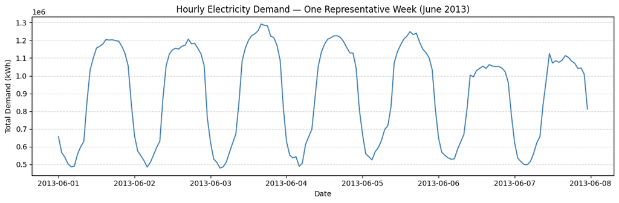

```python
one_week = neighbourhood_demand["total_demand"]["2013-06-01":"2013-06-07"]

plt.figure(figsize=(12, 4))
plt.plot(one_week.index, one_week.values, color="steelblue", linewidth=1.5)
plt.title("Hourly Electricity Demand — One Representative Week (June 2013)")
plt.xlabel("Date")
plt.ylabel("Total Demand (kWh)")
plt.grid(axis="y", linestyle="--", alpha=0.5)
plt.tight_layout()
plt.show()
```

### Peak Demand Heatmap — Hour vs Day of Week

A heatmap of average electricity demand across hours of the day and days of the week provides a two-dimensional view of consumption behaviour that line and bar charts cannot capture. This visualisation simultaneously reveals which combination of day and hour consistently produces the highest demand, offering actionable insights for smart grid operators to anticipate and manage peak load periods throughout the week.

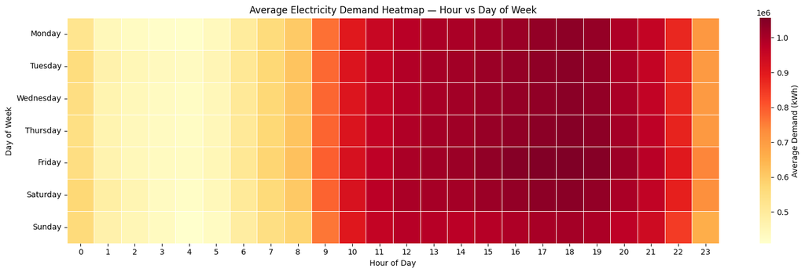

```python
pivot = neighbourhood_demand.groupby(["dayofweek", "hour"])["total_demand"].mean().unstack()
pivot.index = ["Monday", "Tuesday", "Wednesday", "Thursday", "Friday", "Saturday", "Sunday"]

plt.figure(figsize=(16, 5))
sns.heatmap(pivot, cmap="YlOrRd", linewidths=0.5, annot=False, fmt=".0f",
            cbar_kws={"label": "Average Demand (kWh)"})
plt.title("Average Electricity Demand Heatmap — Hour vs Day of Week")
plt.xlabel("Hour of Day")
plt.ylabel("Day of Week")
plt.tight_layout()
plt.show()
```

### Quarterly Demand Distribution — Box Plot

A box plot comparing electricity demand across quarters of the year provides a statistical summary of consumption variability within each season. Unlike average-based plots, box plots reveal the median, interquartile range, and extreme values for each quarter, giving a richer understanding of how demand spreads and fluctuates across different seasonal periods information that is directly relevant to capacity planning in smart city energy systems.

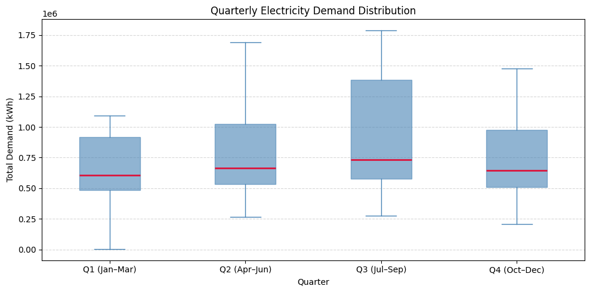

```python
neighbourhood_demand["quarter"] = neighbourhood_demand.index.quarter
quarter_labels = {1: "Q1 (Jan–Mar)", 2: "Q2 (Apr–Jun)",
                  3: "Q3 (Jul–Sep)", 4: "Q4 (Oct–Dec)"}
neighbourhood_demand["quarter_label"] = neighbourhood_demand["quarter"].map(quarter_labels)

plt.figure(figsize=(10, 5))
quarters = [neighbourhood_demand[neighbourhood_demand["quarter"] == q]["total_demand"].values
            for q in [1, 2, 3, 4]]
plt.boxplot(quarters, tick_labels=list(quarter_labels.values()), patch_artist=True,
            boxprops=dict(facecolor="steelblue", color="steelblue", alpha=0.6),
            medianprops=dict(color="crimson", linewidth=2),
            whiskerprops=dict(color="steelblue"),
            capprops=dict(color="steelblue"),
            flierprops=dict(marker="o", markerfacecolor="steelblue", markersize=2, alpha=0.3))
plt.title("Quarterly Electricity Demand Distribution")
plt.xlabel("Quarter")
plt.ylabel("Total Demand (kWh)")
plt.grid(axis="y", linestyle="--", alpha=0.5)
plt.tight_layout()
plt.show()
```

### Demand Autocorrelation — ACF Plot

An autocorrelation function (ACF) plot measures how strongly the electricity demand at any given hour is correlated with its past values at different time lags. Strong autocorrelation at regular intervals such as at lag 24 (daily cycle) and lag 168 (weekly cycle) confirms the presence of repeating temporal patterns in the data. This analysis directly justifies the use of an LSTM network, which is specifically designed to learn and exploit such long-range dependencies in sequential data.

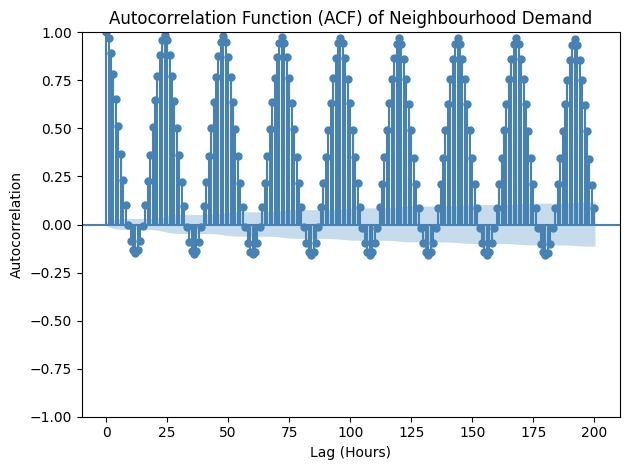

```python
plt.figure(figsize=(12, 4))
plot_acf(neighbourhood_demand["total_demand"].dropna(), lags=200, alpha=0.05,
         color="steelblue", vlines_kwargs={"colors": "steelblue"})
plt.title("Autocorrelation Function (ACF) of Neighbourhood Demand")
plt.xlabel("Lag (Hours)")
plt.ylabel("Autocorrelation")
plt.tight_layout()
plt.show()
```

### Year-on-Year Demand Comparison — Area Chart

Overlaying the demand profiles of each year on the same axis allows for a direct year-on-year comparison of electricity consumption patterns. An area chart is used here to emphasise the volume of demand over time, making it straightforward to identify whether overall consumption is growing, declining, or remaining stable across 2012, 2013, and 2014 — an important consideration for long-term energy infrastructure planning in smart cities.

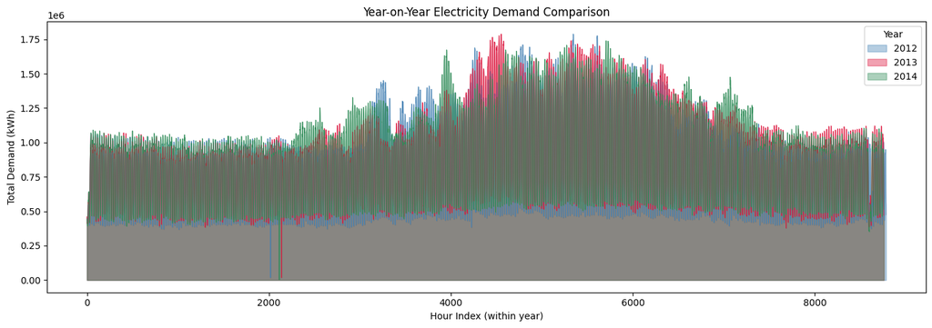

```python
fig, ax = plt.subplots(figsize=(14, 5))

colours = ["steelblue", "crimson", "seagreen"]
for i, year in enumerate([2012, 2013, 2014]):
    yearly = neighbourhood_demand[neighbourhood_demand.index.year == year]["total_demand"]
    yearly = yearly.reset_index(drop=True)
    ax.fill_between(yearly.index, yearly.values, alpha=0.4,
                    color=colours[i], label=str(year))
    ax.plot(yearly.index, yearly.values, color=colours[i], linewidth=0.5)

ax.set_title("Year-on-Year Electricity Demand Comparison")
ax.set_xlabel("Hour Index (within year)")
ax.set_ylabel("Total Demand (kWh)")
ax.legend(title="Year")
plt.tight_layout()
plt.show()
```

### Weekday vs Weekend Demand

A violin plot comparing weekday and weekend electricity demand distributions reveals not just the average difference in consumption between the two groups, but also the full shape of each distribution. The width of the violin at any demand level indicates how frequently that level occurs, providing a nuanced picture of how human activity patterns on working days versus rest days translate into distinctly different electricity demand profiles.

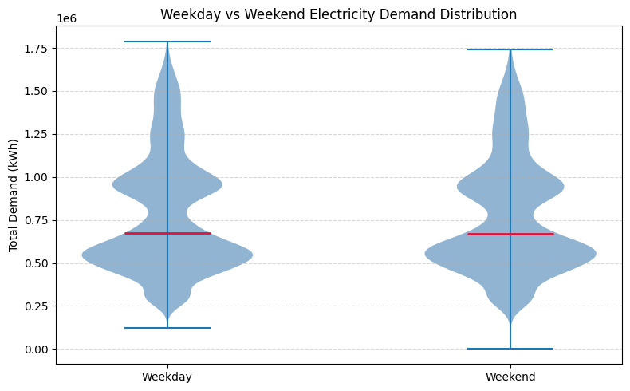

```python
weekday_demand = neighbourhood_demand[neighbourhood_demand["dayofweek"] < 5]["total_demand"]
weekend_demand = neighbourhood_demand[neighbourhood_demand["dayofweek"] >= 5]["total_demand"]

fig, ax = plt.subplots(figsize=(8, 5))
parts = ax.violinplot([weekday_demand.values, weekend_demand.values],
                      positions=[1, 2], showmedians=True, showextrema=True)

for pc in parts["bodies"]:
    pc.set_facecolor("steelblue")
    pc.set_alpha(0.6)
parts["cmedians"].set_color("crimson")
parts["cmedians"].set_linewidth(2)

ax.set_xticks([1, 2])
ax.set_xticklabels(["Weekday", "Weekend"])
ax.set_title("Weekday vs Weekend Electricity Demand Distribution")
ax.set_ylabel("Total Demand (kWh)")
ax.grid(axis="y", linestyle="--", alpha=0.5)
plt.tight_layout()
plt.show()
```

## Data Preparation

Before building the forecasting models, the preprocessed neighbourhood demand data must be structured into supervised learning sequences. A sliding window approach is used where 24 consecutive hours of historical demand serve as the input features and the immediately following hour is the target value to be predicted. The scaled data is then split into training, validation, and test sets using a 70/15/15 ratio, preserving the temporal order of the time series to prevent data leakage. This sequential split ensures that the model is always trained on past data and evaluated on genuinely unseen future data, which accurately simulates real-world forecasting conditions.

```python
def create_sequences(data, lookback=24):
    X, y = [], []
    for i in range(len(data) - lookback):
        X.append(data[i:i+lookback])
        y.append(data[i+lookback])
    return np.array(X), np.array(y)

lookback = 24
X, y = create_sequences(scaled, lookback=lookback)

train_size = int(len(X) * 0.70)
val_size   = int(len(X) * 0.15)

X_train, y_train = X[:train_size],y[:train_size]
X_val,   y_val   = X[train_size:train_size+val_size],y[train_size:train_size+val_size]
X_test,  y_test  = X[train_size+val_size:],y[train_size+val_size:]

print(f"Train:      {X_train.shape}, {y_train.shape}")
print(f"Validation: {X_val.shape},   {y_val.shape}")
print(f"Test:       {X_test.shape},  {y_test.shape}")
```

```
Train:      (24528, 24, 1), (24528, 1)
Validation: (5256, 24, 1),   (5256, 1)
Test:       (5257, 24, 1),  (5257, 1)
```

The sequence creation and train/validation/test split has been completed successfully. The training set contains 24,528 sequences, the validation set contains 5,256 sequences, and the test set contains 5,257 sequences — together accounting for all 35,041 usable hourly records after applying the 24-hour lookback window. Each sequence has the shape (24, 1) confirming that every input sample consists of 24 consecutive hourly demand readings feeding into a single predicted value. The 70/15/15 split ensures the model is trained on approximately three years of data whilst being validated and tested on genuinely unseen future demand periods, accurately replicating real-world forecasting conditions for smart city energy planning.

## Implementation of LSTM Model and CNN-LSTM Model

### LSTM Model - Architecture

The Long Short-Term Memory network is the primary forecasting model in this use case. LSTM networks are specifically designed to learn long-range temporal dependencies in sequential data, making them well-suited to electricity demand forecasting where consumption at any given hour is strongly influenced by patterns from the preceding hours and days as confirmed by the ACF plot during EDA. The architecture consists of two stacked LSTM layers to capture both short-term and medium-term temporal patterns, followed by a Dense output layer that produces the single-step demand forecast. Dropout regularisation of 0.2 is applied after each LSTM layer to prevent overfitting on the training data.

```python
tf.random.set_seed(42)

lstm_model = Sequential([
    Input(shape=(lookback, 1)),
    LSTM(64, return_sequences=True),
    Dropout(0.2),
    LSTM(32, return_sequences=False),
    Dropout(0.2),
    Dense(1)
], name="LSTM_Model")

lstm_model.compile(
    optimizer=tf.keras.optimizers.Adam(learning_rate=0.001),
    loss="mse",
    metrics=["mae"]
)

lstm_model.summary()
```

```
Model: "LSTM_Model"
```

```
┏━━━━━━━━━━━━━━━━━━━━━━━━━━━━━━━━━┳━━━━━━━━━━━━━━━━━━━━━━━━┳━━━━━━━━━━━━━━━┓
┃ Layer (type)                    ┃ Output Shape           ┃       Param # ┃
┡━━━━━━━━━━━━━━━━━━━━━━━━━━━━━━━━━╇━━━━━━━━━━━━━━━━━━━━━━━━╇━━━━━━━━━━━━━━━┩
│ lstm (LSTM)                     │ (None, 24, 64)         │        16,896 │
├─────────────────────────────────┼────────────────────────┼───────────────┤
│ dropout (Dropout)               │ (None, 24, 64)         │             0 │
├─────────────────────────────────┼────────────────────────┼───────────────┤
│ lstm_1 (LSTM)                   │ (None, 32)             │        12,416 │
├─────────────────────────────────┼────────────────────────┼───────────────┤
│ dropout_1 (Dropout)             │ (None, 32)             │             0 │
├─────────────────────────────────┼────────────────────────┼───────────────┤
│ dense (Dense)                   │ (None, 1)              │            33 │
└─────────────────────────────────┴────────────────────────┴───────────────┘
```

```
 Total params: 29,345 (114.63 KB)
```

```
 Trainable params: 29,345 (114.63 KB)
```

```
 Non-trainable params: 0 (0.00 B)
```

The LSTM model summary confirms a clean and well-proportioned architecture with a total of 29,345 trainable parameters. The first LSTM layer processes the 24-hour input sequence and outputs a full sequence of 64-dimensional hidden states across all 24 timesteps, which are then passed to the second LSTM layer. The second LSTM layer reduces this to a single 32-dimensional context vector capturing the most relevant temporal information from the entire input window. The dropout layers contribute zero parameters as expected since they are purely a regularisation mechanism that randomly deactivates neurons during training. The final Dense layer maps the 32-dimensional representation to a single output value representing the forecasted demand for the next hour. The total parameter count of 29,345 is deliberately kept compact to avoid overfitting on the training data whilst still being expressive enough to capture the complex temporal patterns identified during EDA.

### LSTM Model - Training

The LSTM model is trained using the Adam optimiser with a learning rate of 0.001 and mean squared error as the loss function. Two callbacks are employed to optimise the training process EarlyStopping monitors the validation loss and halts training if no improvement is observed for 10 consecutive epochs, restoring the best weights seen during training. ReduceLROnPlateau automatically reduces the learning rate by a factor of 0.5 if the validation loss plateaus for 5 consecutive epochs, allowing the model to fine-tune its weights more precisely as it approaches convergence.

```python
early_stop = EarlyStopping(
    monitor="val_loss", patience=10,
    restore_best_weights=True, verbose=1
)

reduce_lr = ReduceLROnPlateau(
    monitor="val_loss", factor=0.5,
    patience=5, min_lr=1e-6, verbose=1
)

lstm_history = lstm_model.fit(
    X_train, y_train,
    epochs=20,
    batch_size=64,
    validation_data=(X_val, y_val),
    callbacks=[early_stop, reduce_lr],
    verbose=1
)
```

```
384/384 ━━━━━━━━━━━━━━━━━━━━ 5s 9ms/step - loss: 0.0121 - mae: 0.0759 - val_loss: 0.0019 - val_mae: 0.0357 - learning_rate: 0.0010
384/384 ━━━━━━━━━━━━━━━━━━━━ 3s 9ms/step - loss: 0.0033 - mae: 0.0436 - val_loss: 0.0013 - val_mae: 0.0286 - learning_rate: 0.0010
384/384 ━━━━━━━━━━━━━━━━━━━━ 3s 9ms/step - loss: 0.0029 - mae: 0.0405 - val_loss: 0.0016 - val_mae: 0.0315 - learning_rate: 0.0010
384/384 ━━━━━━━━━━━━━━━━━━━━ 3s 9ms/step - loss: 0.0024 - mae: 0.0369 - val_loss: 0.0012 - val_mae: 0.0280 - learning_rate: 0.0010
384/384 ━━━━━━━━━━━━━━━━━━━━ 3s 9ms/step - loss: 0.0020 - mae: 0.0336 - val_loss: 8.6740e-04 - val_mae: 0.0214 - learning_rate: 0.0010
384/384 ━━━━━━━━━━━━━━━━━━━━ 4s 9ms/step - loss: 0.0017 - mae: 0.0304 - val_loss: 9.9083e-04 - val_mae: 0.0228 - learning_rate: 0.0010
384/384 ━━━━━━━━━━━━━━━━━━━━ 3s 9ms/step - loss: 0.0015 - mae: 0.0284 - val_loss: 8.6395e-04 - val_mae: 0.0210 - learning_rate: 0.0010
384/384 ━━━━━━━━━━━━━━━━━━━━ 4s 9ms/step - loss: 0.0013 - mae: 0.0266 - val_loss: 7.5557e-04 - val_mae: 0.0189 - learning_rate: 0.0010
384/384 ━━━━━━━━━━━━━━━━━━━━ 3s 9ms/step - loss: 0.0012 - mae: 0.0249 - val_loss: 7.3594e-04 - val_mae: 0.0193 - learning_rate: 0.0010
384/384 ━━━━━━━━━━━━━━━━━━━━ 3s 9ms/step - loss: 0.0011 - mae: 0.0246 - val_loss: 7.0552e-04 - val_mae: 0.0189 - learning_rate: 0.0010
384/384 ━━━━━━━━━━━━━━━━━━━━ 4s 9ms/step - loss: 0.0010 - mae: 0.0234 - val_loss: 5.8342e-04 - val_mae: 0.0163 - learning_rate: 0.0010
384/384 ━━━━━━━━━━━━━━━━━━━━ 3s 9ms/step - loss: 0.0010 - mae: 0.0230 - val_loss: 7.2540e-04 - val_mae: 0.0196 - learning_rate: 0.0010
384/384 ━━━━━━━━━━━━━━━━━━━━ 3s 9ms/step - loss: 9.2997e-04 - mae: 0.0221 - val_loss: 5.6171e-04 - val_mae: 0.0165 - learning_rate: 0.0010
384/384 ━━━━━━━━━━━━━━━━━━━━ 3s 9ms/step - loss: 8.6681e-04 - mae: 0.0215 - val_loss: 5.6881e-04 - val_mae: 0.0170 - learning_rate: 0.0010
384/384 ━━━━━━━━━━━━━━━━━━━━ 4s 10ms/step - loss: 8.3987e-04 - mae: 0.0211 - val_loss: 6.3420e-04 - val_mae: 0.0179 - learning_rate: 0.0010
383/384 ━━━━━━━━━━━━━━━━━━━━ 0s 9ms/step - loss: 8.4315e-04 - mae: 0.0212
Epoch 16: ReduceLROnPlateau reducing learning rate to 0.0005000000237487257.
384/384 ━━━━━━━━━━━━━━━━━━━━ 4s 9ms/step - loss: 8.4397e-04 - mae: 0.0213 - val_loss: 4.8829e-04 - val_mae: 0.0157 - learning_rate: 0.0010
384/384 ━━━━━━━━━━━━━━━━━━━━ 4s 9ms/step - loss: 7.3172e-04 - mae: 0.0198 - val_loss: 4.6538e-04 - val_mae: 0.0151 - learning_rate: 5.0000e-04
384/384 ━━━━━━━━━━━━━━━━━━━━ 4s 9ms/step - loss: 7.2709e-04 - mae: 0.0197 - val_loss: 4.9319e-04 - val_mae: 0.0158 - learning_rate: 5.0000e-04
384/384 ━━━━━━━━━━━━━━━━━━━━ 4s 9ms/step - loss: 7.0995e-04 - mae: 0.0195 - val_loss: 4.6165e-04 - val_mae: 0.0152 - learning_rate: 5.0000e-04
384/384 ━━━━━━━━━━━━━━━━━━━━ 4s 10ms/step - loss: 7.0763e-04 - mae: 0.0194 - val_loss: 4.9357e-04 - val_mae: 0.0161 - learning_rate: 5.0000e-04
Restoring model weights from the end of the best epoch: 19.
```

### LSTM Model — Training History Plot

Plotting the training and validation loss curves across all 20 epochs provides a visual confirmation of the model's learning behaviour. A well-trained model should show both curves declining smoothly and converging towards similar low values, with no significant divergence between training and validation loss that would indicate overfitting.

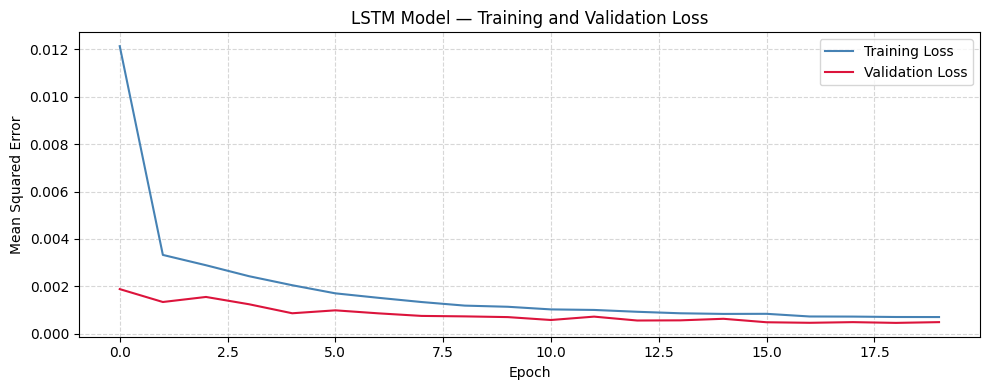

```python
plt.figure(figsize=(10, 4))
plt.plot(lstm_history.history["loss"],
         label="Training Loss",   color="steelblue")
plt.plot(lstm_history.history["val_loss"],
         label="Validation Loss", color="crimson")
plt.title("LSTM Model — Training and Validation Loss")
plt.xlabel("Epoch")
plt.ylabel("Mean Squared Error")
plt.legend()
plt.grid(linestyle="--", alpha=0.5)
plt.tight_layout()
plt.show()
```

### CNN-LSTM Model — Architecture

The Hybrid CNN-LSTM model combines the local feature extraction capability of Convolutional Neural Networks with the sequential memory of LSTM networks. The Conv1D layer acts as an automatic feature extractor, identifying short-term local patterns and motifs within the 24-hour input window — such as the morning ramp-up shape or the evening peak profile — before passing these extracted features to the LSTM layer which models the temporal dependencies across the sequence. This hierarchical architecture allows the model to simultaneously capture both fine-grained local patterns and broader temporal context, making it a potentially more powerful forecasting architecture than a standalone LSTM for complex real-world demand signals.

```python
tf.random.set_seed(42)

inputs = Input(shape=(lookback, 1))
x = Conv1D(filters=64, kernel_size=3, activation="relu", padding="same")(inputs)
x = MaxPooling1D(pool_size=2)(x)
x = Dropout(0.2)(x)
x = LSTM(64, return_sequences=False)(x)
x = Dropout(0.2)(x)
x = Dense(32, activation="relu")(x)
outputs = Dense(1)(x)

cnn_lstm_model = Model(inputs, outputs, name="CNN_LSTM_Model")

cnn_lstm_model.compile(
    optimizer=tf.keras.optimizers.Adam(learning_rate=0.001),
    loss="mse",
    metrics=["mae"]
)

cnn_lstm_model.summary()
```

```
Model: "CNN_LSTM_Model"
```

```
┏━━━━━━━━━━━━━━━━━━━━━━━━━━━━━━━━━┳━━━━━━━━━━━━━━━━━━━━━━━━┳━━━━━━━━━━━━━━━┓
┃ Layer (type)                    ┃ Output Shape           ┃       Param # ┃
┡━━━━━━━━━━━━━━━━━━━━━━━━━━━━━━━━━╇━━━━━━━━━━━━━━━━━━━━━━━━╇━━━━━━━━━━━━━━━┩
│ input_layer_1 (InputLayer)      │ (None, 24, 1)          │             0 │
├─────────────────────────────────┼────────────────────────┼───────────────┤
│ conv1d (Conv1D)                 │ (None, 24, 64)         │           256 │
├─────────────────────────────────┼────────────────────────┼───────────────┤
│ max_pooling1d (MaxPooling1D)    │ (None, 12, 64)         │             0 │
├─────────────────────────────────┼────────────────────────┼───────────────┤
│ dropout_2 (Dropout)             │ (None, 12, 64)         │             0 │
├─────────────────────────────────┼────────────────────────┼───────────────┤
│ lstm_2 (LSTM)                   │ (None, 64)             │        33,024 │
├─────────────────────────────────┼────────────────────────┼───────────────┤
│ dropout_3 (Dropout)             │ (None, 64)             │             0 │
├─────────────────────────────────┼────────────────────────┼───────────────┤
│ dense_1 (Dense)                 │ (None, 32)             │         2,080 │
├─────────────────────────────────┼────────────────────────┼───────────────┤
│ dense_2 (Dense)                 │ (None, 1)              │            33 │
└─────────────────────────────────┴────────────────────────┴───────────────┘
```

```
 Total params: 35,393 (138.25 KB)
```

```
 Trainable params: 35,393 (138.25 KB)
```

```
 Non-trainable params: 0 (0.00 B)
```